# 8 Schools Stan

Russell Almond

1/31/2019

# The 8 Schools Problem

This is the classic eight schools example from Rubin(1981)[^1]. (It is also found in Chapter 5 of Gelman et al., 2014 [^2].) The story is that 8 different schools experimented with an SAT coaching experiment. The performance gains of the coached students were compared to students on a weight list control. Separate estimates were obtained for each school, but because the size of the schools differed, the standard errors differed as well.

Here are the data:

```r
Schools <- data.frame(row.names=c("A","B","C","D","E","F","G","H"),
                      effect = c(28.39,7.94,-2.75,6.82,-.64,.63,18.01,12.16),
                      see = c(14.9, 10.2, 16.3, 11.0, 9.4, 11.4, 10.4, 17.6))
Schools
```

|  | effect | see |
| --- | --- | --- |
| A | 28.39 | 14.9 |
| B | 7.94 | 10.2 |
| C | -2.75 | 16.3 |
| D | 6.82 | 11.0 |
| E | -0.64 | 9.4 |
| F | 0.63 | 11.4 |
| G | 18.01 | 10.4 |
| H | 12.16 | 17.6 |

Lets start by calculating a weighted average effect. I’ll weight each case by the precision (one over the square of the see).

```r
Schools$w <- 1/Schools$see^2
Schools.mean <- sum(Schools$w*Schools$effect)/sum(Schools$w)
Schools.mean
```

```
[1] 7.870546
```

Here is a plot of the data.

```r
ord <- order(Schools$effect)
plot(Schools$effect[ord[c(1,8)]]+c(-2,2)*Schools$see[ord[c(1,8)]],
     c(nrow(Schools),1),main = "8 Schools data.",type="n",yaxt="n",
     xlab="Effect Size",ylab="School")
points(Schools$effect[ord],nrow(Schools):1,pch=rownames(Schools)[ord])
```

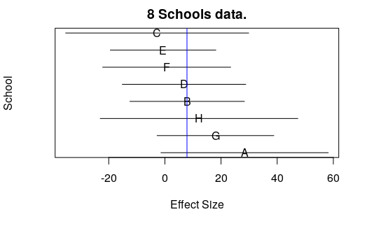

```r
segments(Schools$effect[ord]-2*Schools$see[ord],nrow(Schools):1,
         Schools$effect[ord]+2*Schools$see[ord],nrow(Schools):1)
abline(v=Schools.mean,col="blue")
```

## Model Setup in Stan.

First we need to load the packages. The `rstan` package runs stan from R. The `shinystan` package gives us a browser for the results.

```r
library(rstan)
library(shinystan)
library(parallel) # For using multiple chains
```

### Parts of the stan code.

Almost all models will have a `data`, `parameters` and `model` block. They could have others as well (common ones are `transformed data` to do pre-calculations and `transformed parameters` to recast the model).

#### Data

In a stan model, *data* refers to values that don’t change over the course of the MCMC loop. This tends to be one of three things: * The observed data values. * Fixed hyperparameters for prior distributions. * Structural hyperparamters (e.g., sample size, number of groups).

#### Parameters

The parameters are the values that stan will try to estimate. These include both latent variables and ordinary parameters and hyperparameters.

#### Model

```r
lookup(dnorm)
```

|  | StanFunction | Arguments | ReturnType | Page |
| --- | --- | --- | --- | --- |
| 355 | normal_lpdf | (reals y \| reals mu, reals sigma) | real | 505 |
| 356 | normal | ~ | real | 505 |

```r
lookup(dt)
```

|  | StanFunction | Arguments | ReturnType | Page |
| --- | --- | --- | --- | --- |
| 611 | student_t_lpdf | (reals y \| reals nu, reals mu, reals sigma) | real | 508 |
| 612 | student_t | ~ | real | 508 |

Finally, note that this is an incomplete Bayesian model as there are no distributions for `mu` or `tau`. In stan this means we are implicitly putting a uniform prior on `mu` and `log(tau)`; the latter is transformed so that it will always be positive. These are improper priors, but stan will be fine as long as the posterior is proper.

## Data preparation

Build a list which contains the data as elements using the names in the data section of the model.

```r
school8.dat <- list(
  J = nrow(Schools),
  y = Schools$effect,
  sigma=Schools$see)
```

## Running Stan

There are two funcitons to start the sampling in stan. The first one is `stan(file=XXX,data=YYY,...)`. This assumes that the stan model is in a file. However, with R markdown, we already saved the model in an object so we can use `sampling(model,data=YYY,...)`. By the way, this same function can be used to make additional samples after we have sampled for a while.

The mc.cores should work well for Unix (Linux and Mac OS), I’m not so sure about Windows.

```r
#options(mc.cores = parallel::detectCores()-1)
school8.fit1 <- sampling(
  school8.stan,       # The model
  data = school8.dat, # The data
  chains = 5,
  warmup = 1000,
  iter = 2000,
  refresh=100        # Show progress
)
```

[output not shown]

[output cut: 119 more lines]

[output not shown]

```
There were 410 divergent transitions after warmup. Increasing adapt_delta above 0.8 may help. See
http://mc-stan.org/misc/warnings.html#divergent-transitions-after-warmupThere were 2 chains where the estimated Bayesian Fraction of Missing Information was low. See
http://mc-stan.org/misc/warnings.html#bfmi-lowExamine the pairs() plot to diagnose sampling problems
```

```r
summary(school8.fit1)
```

```
$summary
               mean   se_mean       sd
mu         7.812131 0.6055113 5.608953
tau        6.526100 0.5475959 5.594885
theta[1]  11.406455 0.7937759 8.844209
theta[2]   7.661773 0.7112901 6.728279
theta[3]   6.187038 0.5263840 7.914510
theta[4]   7.449181 0.5391214 6.876766
theta[5]   5.250541 0.5238661 6.588764
theta[6]   6.084175 0.5881689 6.928273
theta[7]  10.227007 0.7628530 7.193739
theta[8]   8.351604 0.6037402 7.949255
lp__     -16.765925 1.0801876 6.665330
                2.5%         25%
mu        -1.9650045   4.0061144
tau        0.4908227   2.4808113
theta[1]  -2.3989105   5.4760790
theta[2]  -4.6237519   2.9270998
theta[3] -11.0406690   0.7400600
theta[4]  -5.3785224   2.4641135
theta[5]  -8.5583917   0.8033183
theta[6]  -8.5682197   0.9106422
theta[7]  -1.3595897   5.5085064
theta[8]  -5.9049507   2.5862723
lp__     -27.6712192 -21.4322308
                50%        75%     97.5%
mu         8.114573  11.627998 18.650955
tau        5.104776   8.894914 20.571063
theta[1]  10.741247  16.130516 32.410127
theta[2]   7.986128  12.038098 21.293496
theta[3]   6.565595  11.655198 20.626196
theta[4]   7.674158  11.928284 21.379169
theta[5]   5.657908  10.159945 17.273066
theta[6]   6.451819  11.236821 18.478337
theta[7]  10.308138  14.461569 26.174680
theta[8]   8.372006  12.716449 24.744555
lp__     -17.660582 -12.808046  1.238644
             n_eff     Rhat
mu        85.80631 1.041245
tau      104.39071 1.031969
```

[output cut: 270 more lines]

```
  theta[8]   8.739287  14.749213
  lp__     -19.476391 -16.229731
          stats
parameter      97.5%
  mu        18.81987
  tau       22.01051
  theta[1]  33.58971
  theta[2]  22.15199
  theta[3]  23.12638
  theta[4]  23.55926
  theta[5]  19.31765
  theta[6]  19.42346
  theta[7]  27.26951
  theta[8]  25.85211
  lp__     -10.04014
```

Alternate style using external file.

```r
options(mc.cores = parallel::detectCores()-1)
school8.fit1 <- stan(
  file="Bayesian/school8.stan",       # The model
  data = school8.dat, # The data
  chains = 5,
  warmup = 1000,
  iter = 2000,
  refresh=100        # Show progress
)
summary(school8.fit1)
```

## Summaries using the base Stan functions

Printing gives summaries of the posterior for the specified parameters. Use the `pars` argument to select what to print.

```r
print(school8.fit1,pars=c("theta","mu","tau","lp__"), probs=c(.1,.5,.9))
```

```
Inference for Stan model: school8.
5 chains, each with iter=2000; warmup=1000; thin=1;
post-warmup draws per chain=1000, total post-warmup draws=5000.

           mean se_mean   sd    10%
theta[1]  11.41    0.79 8.84   1.10
theta[2]   7.66    0.71 6.73  -1.07
theta[3]   6.19    0.53 7.91  -3.19
theta[4]   7.45    0.54 6.88  -0.73
theta[5]   5.25    0.52 6.59  -2.87
theta[6]   6.08    0.59 6.93  -2.05
theta[7]  10.23    0.76 7.19   0.16
theta[8]   8.35    0.60 7.95  -0.71
mu         7.81    0.61 5.61   0.07
tau        6.53    0.55 5.59   0.97
lp__     -16.77    1.08 6.67 -24.32
            50%   90% n_eff Rhat
theta[1]  10.74 22.86   124 1.03
theta[2]   7.99 15.71    89 1.04
theta[3]   6.57 15.20   226 1.02
theta[4]   7.67 15.80   163 1.02
theta[5]   5.66 12.79   158 1.03
theta[6]   6.45 14.28   139 1.02
theta[7]  10.31 19.33    89 1.03
theta[8]   8.37 17.82   173 1.02
mu         8.11 14.39    86 1.04
tau        5.10 13.65   104 1.03
lp__     -17.66 -7.30    38 1.11

Samples were drawn using NUTS(diag_e) at Wed Mar  6 15:53:05 2019.
For each parameter, n_eff is a crude measure of effective sample size,
and Rhat is the potential scale reduction factor on split chains (at
convergence, Rhat=1).
```

```
ci_level: 0.8 (80% intervals)
outer_level: 0.95 (95% intervals)
```

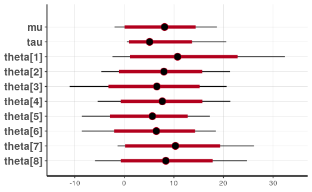

```r
plot(school8.fit1)
```

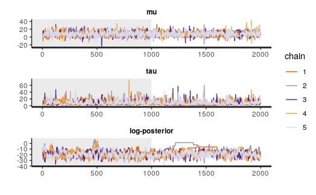

```r
rstan::traceplot(school8.fit1,pars=c("mu","tau","lp__"), inc_warmup=TRUE, nrow=3)
```

What we are looking for here is (a) white-noise like, and all chains plotting over top of each other.

Typically variance and scale parameters will be positively skewed, and log-posterior is often not as well behaved as others.

Pair plot sometimes uncover problems with models.

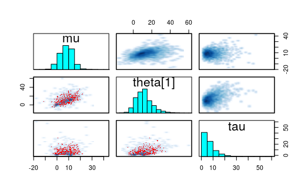

```r
pairs(school8.fit1,pars=c("mu","theta[1]","tau"))
```

## Shinystan

Shinystan opens a new shiny workspace which allows interactive browsing of the results.

```r
school8.fit1s <- launch_shinystan(school8.fit1)
```

```
Launching ShinyStan interface... for large models this  may take some time.

Listening on http://127.0.0.1:3422
```

### References

[^1]: Rubin, D. B. (1981). Estimation in Parallel randomized experiments. *Journal of Educational Statistics*, **6**, 377-401.
[^2]: Gelman, A., Carlin, J. B., Stern, H. S., Dunson, D. B., Vehtari, A. and Rubin, D. B. (2014). *Bayesian Data Analysis: Third Edition*. CRC Press. (ISBN: 978-1-4398-4095-5)